# Analyse détaillée du modèle SIR avec vaccination

Anomalie statistique

2026-04-03

# 1. Introduction : Qu’est-ce qu’un modèle SIR?

Un modèle **SIR** divise une population en trois compartiments :

- **S** (Susceptible) : individus sains pouvant contracter la maladie
- **I** (Infecté) : individus porteurs et transmetteurs de la maladie
- **R** (Retiré/Rétabli) : individus guéris et (temporairement) immunisés

Dans le contexte de Brandell et al. (2020), le modèle SIR est appliqué à **deux niveaux** :

1. **Niveau individuel** : combien d’individus S, I, R dans chaque groupe
2. **Niveau des groupes** : combien de groupes sont classés S, I ou R

# 2. Schéma DAG du modèle SIR original (sans vaccination)

```r
library(DiagrammeR)

grViz("
digraph SIR_original {

  # Configuration générale
  graph [rankdir=LR, fontsize=14, label='\\nModèle SIR original — Niveau individuel (au sein d\\'un groupe infecté)',
         labelloc=t, fontname='Helvetica-Bold', bgcolor='white']
  node  [shape=box, style='filled, rounded', fontname='Helvetica', fontsize=13, width=1.8, height=0.8]
  edge  [fontname='Helvetica', fontsize=11]

  # Compartiments
  S [label='S\\n(Susceptibles)', fillcolor='#ADD8E6']
  I [label='I\\n(Infectés)',     fillcolor='#FFB3B3']
  R [label='R\\n(Rétablis)',     fillcolor='#B3FFB3']

  # Transitions
  S -> I [label='  βw·s·i / (1+s+i+r)  ', color='red',    penwidth=2]
  I -> R [label='  σ (guérison)  ',         color='green',  penwidth=2]
  R -> S [label='  φ (perte immunité)  ',   color='orange', penwidth=2]

  # Mortalité
  I -> mort_I [label='  α (mort maladie)  ', color='gray', style=dashed]
  mort_I [label='†', shape=plaintext, fontsize=18, fillcolor='white', style='']
}
")
```

[interactive chart not shown]

# 3. Schéma DAG du modèle SIR avec VACCINATION

```r
grViz("
digraph SIR_vaccination {

  graph [rankdir=LR, fontsize=14,
         label='\\nModèle SIR avec vaccination — Niveau individuel',
         labelloc=t, fontname='Helvetica-Bold', bgcolor='white']
  node  [shape=box, style='filled, rounded', fontname='Helvetica', fontsize=13, width=1.8, height=0.8]
  edge  [fontname='Helvetica', fontsize=11]

  # Compartiments
  S [label='S\\n(Susceptibles)', fillcolor='#ADD8E6']
  I [label='I\\n(Infectés)',     fillcolor='#FFB3B3']
  R [label='R\\n(Rétablis)',     fillcolor='#B3FFB3']

  # Transitions originales
  S -> I [label='  βw·s·i / (1+s+i+r)  ', color='red',    penwidth=2]
  I -> R [label='  σ (guérison)  ',         color='green',  penwidth=2]
  R -> S [label='  φ (perte immunité)  ',   color='orange', penwidth=2]

  # VACCINATION (nouvelle transition)
  S -> R [label='  ν (vaccination)  ', color='blue', penwidth=3, style=bold]

  # Mortalité
  I -> mort_I [label='  α (mort maladie)  ', color='gray', style=dashed]
  mort_I [label='†', shape=plaintext, fontsize=18, fillcolor='white', style='']
}
")
```

[interactive chart not shown]

# 4. Schéma DAG au niveau des GROUPES

```r
grViz("
digraph SIR_groupes {

  graph [rankdir=LR, fontsize=14,
         label='\\nModèle SIR avec vaccination — Niveau des groupes sociaux',
         labelloc=t, fontname='Helvetica-Bold', bgcolor='white']
  node  [shape=ellipse, style='filled', fontname='Helvetica', fontsize=13, width=2, height=1]
  edge  [fontname='Helvetica', fontsize=11]

  # Groupes
  G [label='G\\nGroupes\\nSusceptibles', fillcolor='#ADD8E6']
  Ig [label='I\\nGroupes\\nInfectés',    fillcolor='#FFB3B3']
  Rg [label='R\\nGroupes\\nRétablis',    fillcolor='#B3FFB3']

  # Transitions originales
  G -> Ig  [label='  β·I·G / (G+I+R)  ', color='red', penwidth=2]
  Ig -> Rg [label='  σ / (1+i)  ',        color='green', penwidth=2]
  Rg -> G  [label='  φ / (1+rR)  ',       color='orange', penwidth=2]

  # VACCINATION — groupes susceptibles deviennent rétablis
  G -> Rg [label='  ν·G (vaccination)  ', color='blue', penwidth=3, style=bold]

  # Réinfection possible
  Rg -> Ig [label='  β·I·R·(sR/(sR+rR))\\n/ (G+I+R)  ', color='darkred', penwidth=1.5, style=dashed]
}
")
```

[interactive chart not shown]

# 5. Explication DÉTAILLÉE de chaque équation du modèle SIR

## 5.1 Variables d’état

### Niveau individuel (au sein des groupes)

| Variable | Description |
| --- | --- |
| $g$ | Nombre moyen d’individus susceptibles dans un **groupe susceptible (G)** |
| $s$ | Nombre moyen d’individus susceptibles dans un **groupe infecté (I)** |
| $i$ | Nombre moyen d’individus infectés dans un **groupe infecté (I)** |
| $r$ | Nombre moyen d’individus rétablis dans un **groupe infecté (I)** |
| $s_R$ | Nombre moyen d’individus susceptibles dans un **groupe rétabli (R)** |
| $r_R$ | Nombre moyen d’individus rétablis dans un **groupe rétabli (R)** |

### Niveau des groupes

| Variable | Description |
| --- | --- |
| $G$ | Nombre de groupes **susceptibles** (aucun individu infecté) |
| $I$ | Nombre de groupes **infectés** (au moins un individu infecté) |
| $R$ | Nombre de groupes **rétablis** (tous les individus guéris) |

## 5.2 Paramètres

| Symbole | Nom | Description |
| --- | --- | --- |
| $B_f$ | Femelles reproductrices | Nombre de femelles qui se reproduisent dans un groupe |
| $b_f$ | Fécondité | Nombre de petits par femelle reproductrice |
| $d$ | Mortalité | Taux de mortalité naturelle par individu |
| $f$ | Fission | Taux auquel un groupe se divise en deux |
| $g_f$ | Taille critique | Taille de groupe au-delà de laquelle la fission augmente |
| $c$ | Fusion | Taux auquel deux groupes fusionnent |
| $a$ | Agression | Taux de mortalité dû à l’agression intergroupe |
| $e$ | Extinction | Taux d’extinction des groupes |
| $\beta$ | Transmission intergroupe | Taux de transmission entre groupes G/R et I |
| $\beta_w$ | Transmission intragroupe | Taux de transmission au sein d’un groupe infecté |
| $\sigma$ | Guérison | Taux de récupération des individus infectés |
| $\alpha$ | Mortalité maladie | Taux de mortalité supplémentaire dû à la maladie |
| $\phi$ | Perte d’immunité | Taux auquel un individu rétabli redevient susceptible |
| $\nu$ | **VACCINATION** | **Nouveau : taux auquel on vaccine les susceptibles (S → R)** |

## 5.3 Équations du modèle — Niveau individuel

### Équation 13 : Susceptibles dans un groupe susceptible ($g$)

$$\frac{dg}{dt} = \underbrace{B_f \cdot
b_f}_{\text{naissances}} - \underbrace{(d + a) \cdot g}_{\text{mortalité
+ agression}} - \underbrace{\frac{f \cdot g^2}{(g_f + g) \cdot
\frac{d}{c+d}}}_{\text{perte par fission}} - \underbrace{e \cdot g \cdot
(G + I + R)}_{\text{extinction}}$$

**Terme par terme :**

- $B_f \cdot b_f$ : Les femelles reproductrices produisent des petits. C’est le seul terme **positif** (entrée de nouveaux individus).
- $(d+a) \cdot g$ : Les individus meurent naturellement ($d$) ou par agression intergroupe ($a$).
- $\frac{f \cdot g^2}{(g_f + g) \cdot \frac{d}{c+d}}$ : Quand le groupe devient grand ($g > g_f$), des individus partent par fission. Le terme $\frac{d}{c+d}$ représente la probabilité qu’un groupe fissionné ne refusionne pas.
- $e \cdot g \cdot (G+I+R)$ : Le groupe peut s’éteindre, et ce risque augmente avec le nombre total de groupes.

### Équation 14 : Susceptibles dans un groupe infecté ($s$)

$$\frac{ds}{dt} = \underbrace{B_f b_f
\frac{s+r}{0.001+s+r}}_{\text{naissances}} - \underbrace{(d+a)
s}_{\text{mortalité}} + \underbrace{\phi \cdot r}_{\text{perte
immunité}} - \underbrace{\frac{s \cdot
f(s+i+r)}{(g_f+s+i+r)\frac{d}{c+d}}}_{\text{fission}} - \underbrace{e
\cdot s(G+I+R)}_{\text{extinction}} - \underbrace{\frac{\beta_w \cdot s
\cdot i}{1+s+i+r}}_{\text{infection}}$$

**Terme par terme :**

- **Naissances** : Seuls les individus sains ($s$) et rétablis ($r$) se reproduisent. Les infectés ($i$) ne se reproduisent pas. Le $0.001$ évite une division par zéro.
- **Mortalité naturelle + agression** : Comme pour $g$.
- **Perte d’immunité** ($\phi \cdot r$) : Les rétablis redeviennent susceptibles. Ce terme est **positif** pour $s$ (on reçoit des individus).
- **Fission** : Même logique que pour $g$, mais la taille totale du groupe est $s+i+r$.
- **Extinction** : Comme pour $g$.
- **Infection** ($\frac{\beta_w \cdot s \cdot i}{1+s+i+r}$) : C’est LE terme clé. Le taux de transmission dépend du nombre de contacts entre susceptibles ($s$) et infectés ($i$). La division par $1+s+i+r$ est une transmission **fréquence-dépendante** (la probabilité de contact dépend de la proportion d’infectés, pas du nombre absolu).

### Équation 15 : Infectés dans un groupe infecté ($i$)

$$\frac{di}{dt} =
\underbrace{\frac{\beta_w \cdot s \cdot i}{1+s+i+r}}_{\text{nouvelles
infections}} - \underbrace{(d + \sigma + \alpha + a) \cdot
i}_{\text{sorties}} - \underbrace{e \cdot i \cdot
(G+I+R)}_{\text{extinction}}$$

**Terme par terme :**

- **Nouvelles infections** : Exactement le même terme que dans l’éq. 14, mais ici il est **positif** (les $s$ infectés deviennent des $i$).
- **Sorties** : Les infectés peuvent :
  - Mourir naturellement ($d$)
  - Guérir ($\sigma$) → ils passent dans $r$
  - Mourir de la maladie ($\alpha$)
  - Mourir par agression ($a$)
- **Extinction** : Comme pour $g$.

**Note importante :** Les infectés NE se reproduisent PAS et NE participent PAS à la fission. Ils ne font que mourir ou guérir.

### Équation 16 : Rétablis dans un groupe infecté ($r$)

$$\frac{dr}{dt} = \underbrace{\sigma \cdot
i}_{\text{guérison}} - \underbrace{(d + \phi + a) \cdot
r}_{\text{sorties}} - \underbrace{\frac{r \cdot
f(s+i+r)}{(g_f+s+i+r)\frac{d}{c+d}}}_{\text{fission}} - \underbrace{e
\cdot r \cdot (G+I+R)}_{\text{extinction}}$$

**Terme par terme :**

- **Guérison** ($\sigma \cdot i$) : Les infectés guérissent et deviennent des rétablis. C’est le terme **positif**.
- **Mortalité + perte immunité + agression** : $d$ (mort naturelle), $\phi$ (redevient susceptible — part vers $s$), $a$ (agression).
- **Fission + extinction** : Comme pour $s$.

### Équation 17 : Susceptibles dans un groupe rétabli ($s_R$)

$$\frac{ds_R}{dt} = \underbrace{B_f b_f
\frac{s_R+r_R}{0.001+s_R+r_R}}_{\text{naissances}} - \underbrace{(d+a)
s_R}_{\text{mortalité}} + \underbrace{\phi \cdot r_R}_{\text{perte
immunité}} - \underbrace{\frac{(s_R+r_R) \cdot f \cdot
s_R}{(g_f+s_R+r_R)\frac{d}{c+d}}}_{\text{fission}} - \underbrace{e \cdot
s_R(G+I+R)}_{\text{extinction}}$$

**Identique à l’éq. 14 SAUF :** il n’y a **pas de terme d’infection**. Les groupes rétablis n’ont pas d’infectés à l’intérieur.

### Équation 18 : Rétablis dans un groupe rétabli ($r_R$)

$$\frac{dr_R}{dt} =
\underbrace{\frac{\sigma \cdot i}{1+i}}_{\text{guérison transférée}} -
\underbrace{(d + \phi + a) \cdot r_R}_{\text{sorties}} -
\underbrace{\frac{(s_R+r_R) \cdot r_R \cdot
f}{(g_f+s_R+r_R)\frac{d}{c+d}}}_{\text{fission}} - \underbrace{e \cdot
r_R(G+I+R)}_{\text{extinction}}$$

**Note :** Le terme $\frac{\sigma \cdot i}{1+i}$ représente les individus guéris qui arrivent dans les groupes rétablis ($R$). La division par $1+i$ modère ce flux.

## 5.4 Équations du modèle — Niveau des groupes

### Équation 19 : Groupes susceptibles ($G$)

$$\frac{dG}{dt} = \underbrace{\frac{G
\cdot c \cdot f \cdot g^2}{(g_f+g)(d+c)}}_{\text{fission crée des
groupes}} - \underbrace{a \cdot G}_{\text{agression}} - \underbrace{e
\cdot G(G+I+R)}_{\text{extinction}} + \underbrace{\frac{R \cdot
\phi}{1+r_R}}_{\text{R redevient G}} - \underbrace{\frac{\beta \cdot I
\cdot G}{G+I+R}}_{\text{infection intergroupe}}$$

**Terme par terme :**

- **Fission** : Quand $g$ est grand, le groupe se divise → on gagne un nouveau groupe $G$.
- **Agression** : Des groupes sont détruits par agression.
- **Extinction** : Extinction densité-dépendante.
- **$R → G$** : Quand les rétablis d’un groupe $R$ perdent leur immunité ($\phi$), le groupe redevient $G$.
- **Infection intergroupe** : Un groupe $G$ rencontre un groupe $I$ et devient infecté → il quitte $G$ et entre dans $I$.

### Équation 20 : Groupes infectés ($I$)

$$\frac{dI}{dt} = \underbrace{\frac{\beta
\cdot I \cdot \left(G + R
\frac{s_R}{s_R+r_R}\right)}{G+I+R}}_{\text{infection de G et R}} -
\underbrace{a \cdot I}_{\text{agression}} - \underbrace{e \cdot
I(G+I+R)}_{\text{extinction}} -
\underbrace{\frac{I(\alpha+\sigma)}{1+i}}_{\text{guérison/mort du
groupe}}$$

**Terme par terme :**

- **Infection** : Un groupe $I$ peut infecter un groupe $G$ (totalement susceptible) ou un groupe $R$ (partiellement susceptible, pondéré par $\frac{s_R}{s_R+r_R}$).
- **Guérison/mort du groupe** : Quand tous les infectés $i$ guérissent ($\sigma$) ou meurent ($\alpha$), le groupe quitte $I$.

### Équation 21 : Groupes rétablis ($R$)

$$\frac{dR}{dt} = \underbrace{\frac{I
\cdot \sigma}{1+i}}_{\text{guérison}} + \underbrace{\frac{c \cdot f
\cdot R(s_R+r_R)^2}{(g_f+s_R+r_R)(c+d)}}_{\text{fission}} -
\underbrace{a \cdot R}_{\text{agression}} - \underbrace{e \cdot
R(G+I+R)}_{\text{extinction}} - \underbrace{\frac{R \cdot
\phi}{1+r_R}}_{\text{perte immunité}} - \underbrace{\frac{\beta \cdot I
\cdot R \frac{s_R}{s_R+r_R}}{G+I+R}}_{\text{réinfection}}$$

# 6. Ajout de la VACCINATION au modèle

## 6.1 Concept

La vaccination prend des individus **susceptibles (S)** et les rend directement **rétablis (R)**, sans passer par l’infection. On ajoute un paramètre $\nu$ (nu) = **taux de vaccination**.

## 6.2 Modifications aux équations

### Niveau individuel

**Éq. 13 modifiée** (susceptibles dans groupe susceptible) :
$$\frac{dg}{dt} = B_f b_f - (d
+ a + \nu) \cdot g - \frac{f g^2}{(g_f+g)\frac{d}{c+d}} - e \cdot
g(G+I+R)$$

Le terme $\nu \cdot g$ est ajouté : des susceptibles sont vaccinés et quittent $g$.

**Éq. 14 modifiée** (susceptibles dans groupe infecté) :
$$\frac{ds}{dt} = B_f b_f
\frac{s+r}{0.001+s+r} - (d+a+\nu) \cdot s + \phi \cdot r - \frac{s
f(s+i+r)}{(g_f+s+i+r)\frac{d}{c+d}} - e \cdot s(G+I+R) - \frac{\beta_w s
i}{1+s+i+r}$$

**Éq. 16 modifiée** (rétablis dans groupe infecté) — on recoit les vaccinés :
$$\frac{dr}{dt} =
\sigma i + \nu \cdot s - (d + \phi + a) r - \frac{r
f(s+i+r)}{(g_f+s+i+r)\frac{d}{c+d}} - e \cdot r(G+I+R)$$

**Éq. 17 modifiée** (susceptibles dans groupe rétabli) :
$$\frac{ds_R}{dt} = B_f b_f
\frac{s_R+r_R}{0.001+s_R+r_R} - (d+a+\nu) s_R + \phi r_R -
\frac{(s_R+r_R) f s_R}{(g_f+s_R+r_R)\frac{d}{c+d}} - e \cdot
s_R(G+I+R)$$

**Éq. 18 modifiée** (rétablis dans groupe rétabli) :
$$\frac{dr_R}{dt} = \frac{\sigma i}{1+i} +
\nu \cdot s_R - (d + \phi + a) r_R - \frac{(s_R+r_R) r_R
f}{(g_f+s_R+r_R)\frac{d}{c+d}} - e \cdot r_R(G+I+R)$$

### Niveau des groupes

Les équations des groupes (19-21) restent **inchangées** si on considère que la vaccination n’agit que sur les individus. Si on veut qu’un groupe entièrement vacciné devienne un groupe $R$, il faut ajouter un terme $\nu \cdot G$ à l’éq. 21 et le retirer de l’éq. 19.

## 6.3 Implémentation du modèle SIR + vaccination

```r
library(deSolve)

# Paramètres
d    <- 0.12   # mortalité naturelle
f    <- 0.01   # fission
gf   <- 8      # taille critique de fission
c_   <- 4      # fusion (on évite le conflit avec la fonction c())
e    <- 0.001  # extinction
Bf   <- 1      # femelles reproductrices
bf   <- 3      # petits par femelle
a    <- 0.01   # agression
beta <- 15     # transmission intergroupe
betaw <- 35    # transmission intragroupe
alpha <- 1     # mortalité maladie
sigma <- 12    # guérison
phi   <- 0.25  # perte d'immunité
nu    <- 0     # taux de vaccination (à varier)

# Conditions initiales
G0  <- 5;  I0  <- 2;  R0  <- 1
g0  <- 7;  s0  <- 0;  i0  <- 10
r0  <- 0;  sR0 <- 1;  rR0 <- 6

# Modèle SIR avec vaccination
Modele_SIR_Vaccin <- function(t, x, parms) {

  G  <- max(x[1], 0)
  I  <- max(x[2], 0)
  g  <- max(x[3], 0)
  s  <- max(x[4], 0)
  i  <- max(x[5], 0)
  r  <- max(x[6], 0)
  R  <- max(x[7], 0)
  sR <- max(x[8], 0)
  rR <- max(x[9], 0)

  with(as.list(parms), {

    # --- Niveau individuel ---

    # Éq. 13 modifiée : susceptibles dans groupe susceptible
    # AJOUT: -nu*g (les vaccinés quittent g)
    dg <- Bf*bf - (d + a + nu)*g - (g*g*f)/((gf+g)*(d/(c_+d))) - e*g*(G+I+R)

    # Éq. 14 modifiée : susceptibles dans groupe infecté
    # AJOUT: -nu*s dans le terme (d+a+nu)*s
    ds <- Bf*bf*((s+r)/(0.001+s+r)) - (d + a + nu)*s + phi*r -
          s*f*(s+i+r)/((gf+s+i+r)*(d/(c_+d))) - e*s*(G+I+R) -
          (betaw*s*i)/(1+s+i+r)

    # Éq. 15 : infectés dans groupe infecté (INCHANGÉE — on ne vaccine pas les infectés)
    di <- (betaw*s*i)/(1+s+i+r) - (d + sigma + alpha + a)*i - e*i*(G+I+R)

    # Éq. 16 modifiée : rétablis dans groupe infecté
    # AJOUT: +nu*s (les susceptibles vaccinés rejoignent r)
    dr <- sigma*i + nu*s - (d + phi + a)*r -
          r*f*(s+i+r)/((gf+s+i+r)*(d/(c_+d))) - e*r*(G+I+R)

    # Éq. 17 modifiée : susceptibles dans groupe rétabli
    # AJOUT: -nu*sR
    dsR <- Bf*bf*((sR+rR)/(0.001+sR+rR)) - (d + a + nu)*sR + phi*rR -
           ((sR+rR)*f*sR)/((gf+sR+rR)*(d/(c_+d))) - e*sR*(G+I+R)

    # Éq. 18 modifiée : rétablis dans groupe rétabli
    # AJOUT: +nu*sR (les susceptibles vaccinés rejoignent rR)
    drR <- sigma*i/(1+i) + nu*sR - (d + phi + a)*rR -
           ((sR+rR)*rR*f)/((gf+sR+rR)*(d/(c_+d))) - e*rR*(G+I+R)

    # --- Niveau des groupes ---

    # Éq. 19 : groupes susceptibles (INCHANGÉE)
    dG <- (G*c_*f*g*g)/((gf+g)*(d+c_)) - a*G - e*G*(G+I+R) +
          R*phi/(1+rR) - beta*I*G/(G+I+R)

    # Éq. 20 : groupes infectés (INCHANGÉE)
    dI <- beta*I*(G+(R*(sR/(sR+rR))))/(G+I+R) - a*I - e*I*(G+I+R) -
          I*((alpha+sigma)/(1+i))

    # Éq. 21 : groupes rétablis (INCHANGÉE)
    dR <- I*sigma/(1+i) + (c_*f*R*((sR+rR)^2))/((gf+sR+rR)*(c_+d)) -
          a*R - e*R*(G+I+R) - R*phi/(1+rR) -
          beta*I*(R*(sR/(sR+rR)))/(G+I+R)

    res <- c(dG, dI, dg, ds, di, dr, dR, dsR, drR)
    list(res)
  })
}
```

## 6.4 Comparaison: effet de la vaccination

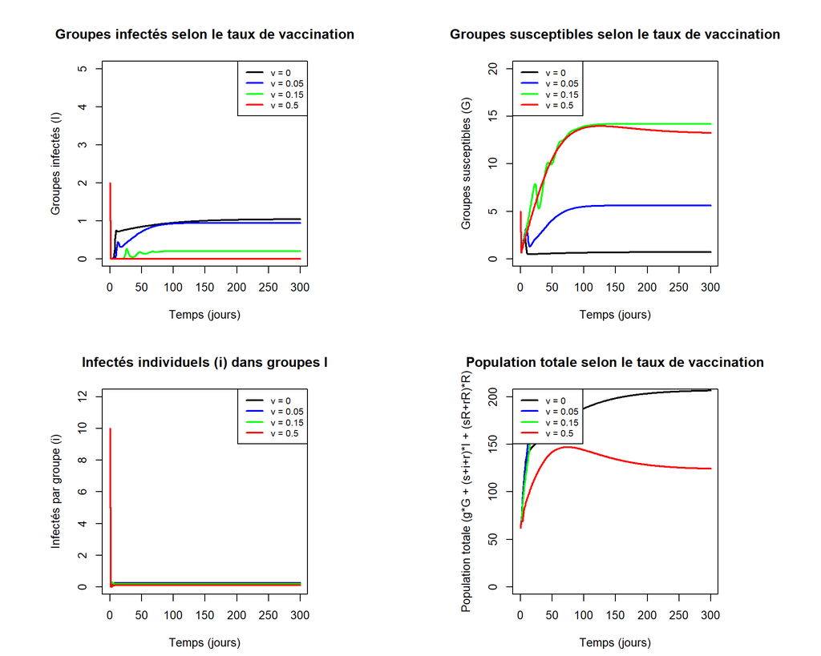

```r
ic    <- c(G=G0, I=I0, g=g0, s=s0, i=i0, r=r0, R=R0, sR=sR0, rR=rR0)
times <- seq(0, 300, by=1)

# Tester différents taux de vaccination
nu_values <- c(0, 0.05, 0.15, 0.5)
colors    <- c("black", "blue", "green", "red")

par(mfrow=c(2,2), pty="s", pin=c(2.5, 2.5))

# --- Panneau 1 : Nombre de groupes infectés (I) ---
plot(NULL, xlim=c(0,300), ylim=c(0, max(I0+2, 5)),
     xlab="Temps (jours)", ylab="Groupes infectés (I)",
     main="Groupes infectés selon le taux de vaccination")

for(j in seq_along(nu_values)) {
  parms <- c(d=d, f=f, gf=gf, c_=c_, e=e, Bf=Bf, bf=bf, a=a,
             beta=beta, betaw=betaw, alpha=alpha, sigma=sigma, phi=phi,
             nu=nu_values[j])
  sol <- ode(ic, times, Modele_SIR_Vaccin, parms,
             maxsteps=1e6, method="vode")
  lines(sol[,"time"], sol[,"I"], col=colors[j], lwd=2)
}
legend("topright", legend=paste("ν =", nu_values), col=colors, lwd=2, cex=0.8)

# --- Panneau 2 : Nombre de groupes susceptibles (G) ---
plot(NULL, xlim=c(0,300), ylim=c(0, 20),
     xlab="Temps (jours)", ylab="Groupes susceptibles (G)",
     main="Groupes susceptibles selon le taux de vaccination")

for(j in seq_along(nu_values)) {
  parms <- c(d=d, f=f, gf=gf, c_=c_, e=e, Bf=Bf, bf=bf, a=a,
             beta=beta, betaw=betaw, alpha=alpha, sigma=sigma, phi=phi,
             nu=nu_values[j])
  sol <- ode(ic, times, Modele_SIR_Vaccin, parms,
             maxsteps=1e6, method="vode")
  lines(sol[,"time"], sol[,"G"], col=colors[j], lwd=2)
}
legend("topleft", legend=paste("ν =", nu_values), col=colors, lwd=2, cex=0.8)

# --- Panneau 3 : Infectés individuels (i) dans groupes infectés ---
plot(NULL, xlim=c(0,300), ylim=c(0, 12),
     xlab="Temps (jours)", ylab="Infectés par groupe (i)",
     main="Infectés individuels (i) dans groupes I")

for(j in seq_along(nu_values)) {
  parms <- c(d=d, f=f, gf=gf, c_=c_, e=e, Bf=Bf, bf=bf, a=a,
             beta=beta, betaw=betaw, alpha=alpha, sigma=sigma, phi=phi,
             nu=nu_values[j])
  sol <- ode(ic, times, Modele_SIR_Vaccin, parms,
             maxsteps=1e6, method="vode")
  lines(sol[,"time"], sol[,"i"], col=colors[j], lwd=2)
}
legend("topright", legend=paste("ν =", nu_values), col=colors, lwd=2, cex=0.8)

# --- Panneau 4 : Population totale ---
plot(NULL, xlim=c(0,300), ylim=c(0, 200),
     xlab="Temps (jours)", ylab="Population totale (g*G + (s+i+r)*I + (sR+rR)*R)",
     main="Population totale selon le taux de vaccination")

for(j in seq_along(nu_values)) {
  parms <- c(d=d, f=f, gf=gf, c_=c_, e=e, Bf=Bf, bf=bf, a=a,
             beta=beta, betaw=betaw, alpha=alpha, sigma=sigma, phi=phi,
             nu=nu_values[j])
  sol <- ode(ic, times, Modele_SIR_Vaccin, parms,
             maxsteps=1e6, method="vode")
  pop_total <- sol[,"g"]*sol[,"G"] + (sol[,"s"]+sol[,"i"]+sol[,"r"])*sol[,"I"] +
               (sol[,"sR"]+sol[,"rR"])*sol[,"R"]
  lines(sol[,"time"], pop_total, col=colors[j], lwd=2)
}
legend("topleft", legend=paste("ν =", nu_values), col=colors, lwd=2, cex=0.8)
```

# 7. Résumé des flux — Tableau récapitulatif

| Transition | Direction | Taux | Signification |
| --- | --- | --- | --- |
| S → I | Infection | $\frac{\beta_w \cdot s \cdot i}{1+s+i+r}$ | Contact entre susceptibles et infectés dans le même groupe |
| I → R | Guérison | $\sigma$ | L’individu guérit et acquiert une immunité |
| R → S | Perte immunité | $\phi$ | L’immunité s’estompe avec le temps |
| S → R | **Vaccination** | $\nu$ | **Le susceptible est vacciné et devient directement immunisé** |
| I → † | Mort maladie | $\alpha$ | L’infection tue l’individu |
| Tout → † | Mort naturelle | $d$ | Mortalité de fond |
| G → I | Infection groupe | $\frac{\beta \cdot I \cdot G}{G+I+R}$ | Un groupe susceptible rencontre un groupe infecté |
| I → R | Guérison groupe | $\frac{\sigma}{1+i}$ | Tous les infectés du groupe guérissent |
| R → G | Perte immunité | $\frac{\phi}{1+r_R}$ | Les rétablis du groupe perdent leur immunité |